# Análise Descritiva Temporal das Taxas de Homicídio no Estado da Paraíba

Iago Flávio

Alex Cordeiro

# Introdução

- De acordo com o Anuário Brasileiro de Segurança Pública, de 2023, o Nordeste está em queda nas taxas de violência letal com uma **queda de 4.2%** em relação a 2022.
- Mesmo com essa queda, a região possui a maior taxa de Mortes Violentas Intencionais (MVI) do país.
- **Taxa de MVI do Brasil em 2023: 23,4** (a cada 100 mil habitantes)
- **Taxa de MVI no Nordeste em 2023: 36,9** (a cada 100 mil habitantes)

## Homicídio e Educação

Com a revisão da literatura, encontrou-se evidências de que a educação é um fator de proteção contra o homicídio. (Gleditsch; Rivera; Zárate-tenorio, 2021)

Entretanto, verificou-se que não há estudos que evidenciem essa correlação na região Nordeste, mais especificamente no estado da Paraíba.

Entre 2010 e 2022, o Brasil vivenciou mudanças significativas tanto nas políticas de segurança pública quanto nas políticas educacionais, com destaque para programas voltados à redução das desigualdades educacionais.

## Homicídio e Educação

Esse estudo é fundamental para entender as dinâmicas sociais e econômicas subjacentes à violência na região. Além disso, tal análise pode fornecer subsídios valiosos para a formulação de políticas públicas integradas, que priorizem o fortalecimento do sistema educacional como uma estratégia para a prevenção e redução do homicídio.

## Objetivos

Objetiva-se por meio desse estudo, realizar uma análise descritiva dos dados sobre mortalidade na Paraíba, entre os anos de 2010 a 2022, a fim de encontrar evidências da correlação das taxas de homicídio com a baixa escolaridade, além de encontrar o perfil mais comum entre as vítimas de homicídio no estado.

# Metodologia

## Origem dos dados

- Foram utilizados os dados disponibilizados pelo Departamento de Informática do Sistema Único de Saúde (DATASUS), mais especificamente, microdados do Sistema de Informação sobre Mortalidade (SIM).
- Esses microdados centralizam as Declarações de Óbito (DO) de todo território nacional.
- Além disso, foram utilizadas estimativas populacionais do IBGE (Instituto Brasileiro de Geografia e Estatística) para calcular a taxa de homicídio.

## Período temporal e região

A região adotada foi o Nordeste, justificada por ser a região com pior índice de pobreza do Brasil, e mais especificamente o estado da Paraíba, devido ao estado apresentar altas taxas de pobreza em relação ao Brasil (2022 - 52,7%, 2023 - 47,5%; PNAD-C, IBGE), tornando-a uma das mais interessantes para aplicar o estudo.

Ademais, percebe-se que mesmo com a queda na taxa de homicídio (IPEA), é aparente a carência das necessidades básicas no estado.

## Período temporal e região

Foram coletados os dados do período de 2010 a 2022, do estado da Paraíba, visto que existe uma carência de estudos voltados a evolução das taxas de homicídio correlacionados a educação, nessa região.

Além disso, de acordo com os dados do Instituto de Pesquisa Econômica Aplicada (IPEA), houve uma queda nas taxas de homicídio na Paraíba, após o ano de 2010, justificando a escolha do período abordado.

## Extração e tratamento dos dados do SIM

- Primeiramente, foi realizado o download dos dados através da plataforma do DATASUS, mais especificamente através do SIM, do período selecionado para análise (2010 a 2022).
- A formatação inicial é em .DBC (Database File Compressed), uma forma compactada do arquivo em .DBF (Database File), e tornou-se necessária a utilização da biblioteca `pyreaddbc`. Essa biblioteca roda apenas em sistemas de arquitetura Linux, o que gerou dificuldade no processo de extração.

## Extração e tratamento dos dados do SIM

Após a conversão dos arquivos para .DBF, foi realizada a leitura dos dados através da biblioteca `dbfread` e convertemos em objetos da classe `DataFrame` da biblioteca `pandas`.

## Extração e tratamento dos dados do IBGE

Foi realizada a leitura dos dados do IBGE, que vieram no formato inicial `.csv`, através da função `read_csv()` da biblioteca `pandas` e convertemos em objetos da classe `DataFrame`. Os dados foram tratados na hora da leitura.

## Tratamento dos dados

Realizou-se a verificação da tipagem dos dados e a conversão dos mesmos para utilização na análise.

Foi observado que aproximadamente 74% dos dados ou estavam vazios ou a escolaridade foi ignorada. A fim de alcançar o objetivo do estudo, foi realizada a remoção dos dados faltantes ou ignorados para a realização do trabalho, facilitando o processo de análise descritiva.

Após a extração e tratamento dos dados do banco de dados do IBGE e do SIM, houve a junção desses dados em um único `DataFrame`, com a finalidade de definir-se as métricas para análise descritiva.

## Definição das métricas

A princípio, através do dicionário de dados do SIM, definiu-se as métricas que correspondem aos dados de identificação das vítimas (escolaridade, idade, sexo, raça/cor, ocupação), e dados gerais (ano, homicídos e população).

## Definição das métricas

|  | Métricas Analisadas | Descrição |
| --- | --- | --- |
| 0 | ANO | Período de tempo em anos |
| 1 | HOMICÍDIOS | Quantidade de homicídios |
| 2 | POPULAÇÃO | Estimativa populacional |
| 3 | IDADE | Idade das vítimas em anos |
| 4 | SEXO | Sexo das vítimas |
| 5 | RAÇA | Raça/cor das vítimas |
| 6 | OCUPAÇÃO | Tipo de trabalho que o falecido desenvolveu |
| 7 | ESCOLARIDADE | Último nível de escolaridade do falecido |

## Análise descritiva

### Calculando taxa de homicídio

- Previamente, foi calculado a quantidade de homicídios por ano entre 2010 a 2022.
- Para calcular a taxa de homicídio, dividiu-se a quantidade total de homicídios ocorridos no devido ano, pela população total, e multiplicou-se por 100 mil. Dessa maneira, obteve-se o resultando na unidade de taxa de homicídio a cada 100 mil habitantes.

## Análise descritiva

### Calculando taxa de homicídio

$$\text{Taxa de Homicídio} = \left( \frac{\text{Número de Homicídios}}{\text{População Total}} \right) \times 100000$$

Comparou-se o resultado com os dados do IPEA (Instituto de Pesquisa Econômica Aplicada) e confirmou-se sua precisão.

## Análise descritiva

### Analisando vítimas de baixa escolaridade

De acordo com a Lei de Diretrizes e Bases da Educação Nacional, a educação básica é composta pelo ensino fundamental e ensino médio.

Assim, filtrou-se as vítimas maiores de 18 anos que não chegaram a completar o ensino médio.

## Análise descritiva

### Análise segmentada por identificação

Após o filtro por baixa escolaridade, foi analisado cada fator de identificação das vítimas: idade, raça/cor, sexo e ocupação.

## Análise descritiva

### Análise perfil mais comum

Criou-se um funil que começa na baixa escolaridade e vai percorrendo os fatores de identificação até que todos sejam filtrados, a fim de encontrar um perfil detalhado mais comum entre as vítimas de homicídio com baixa escolaridade.

# Resultados

## Análise geral

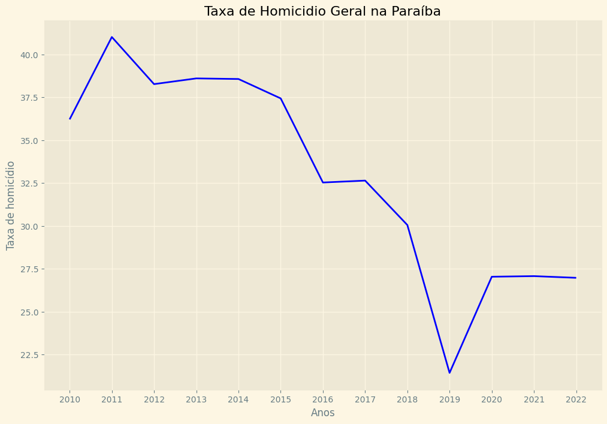

## Análise geral

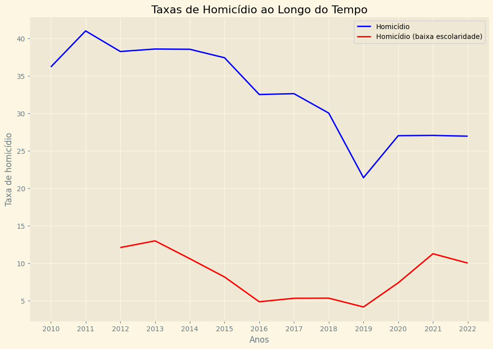

## Análise geral

Percebe-se uma diferença de dispersão das taxas a partir do desvio-padrão, onde a taxa de homicídio geral tem um desvio-padrão de 6.025 e a taxa de homicídio com baixa escolaridade é de 3.174, o que representa uma variação aproximadamente 2x menor.

Isso mostra que a taxa de homicídio para pessoas com baixa escolaridade tende a ser aproximadamente 2x mais constante do que a taxa de homicídio geral na Paraíba nos anos de 2010 a 2022.

## Análise segmentada por idade

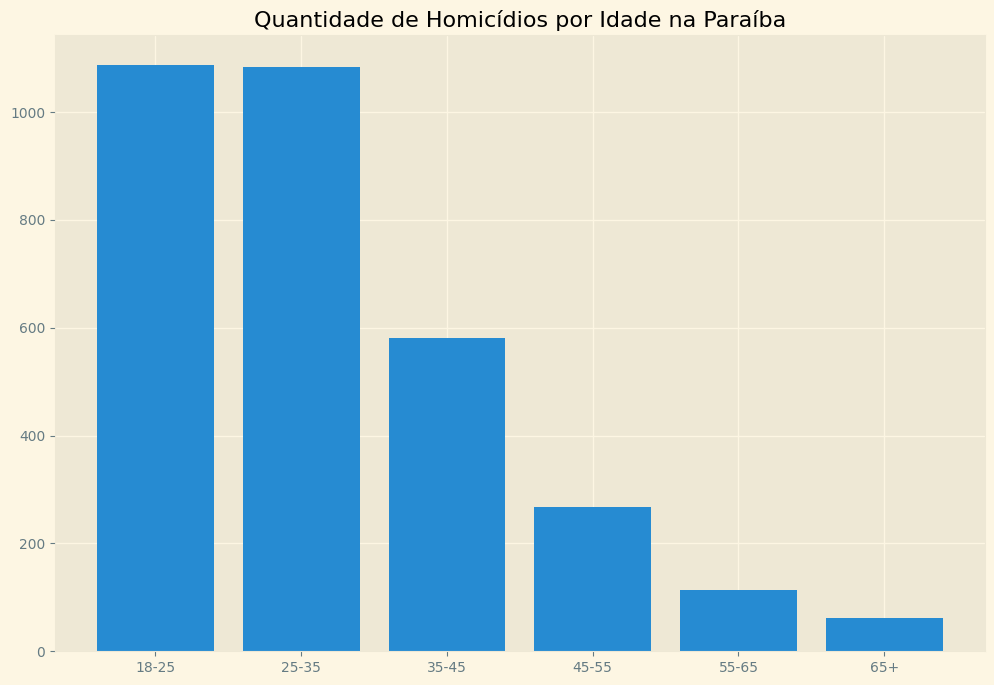

## Análise segmentada por idade

Verificamos uma quantidade de pessoas na faixa de 18-35 anos com elevada mortalidade, onde essa faixa representa aproximadamente 67,96% dos casos.

## Análise segmentada por idade

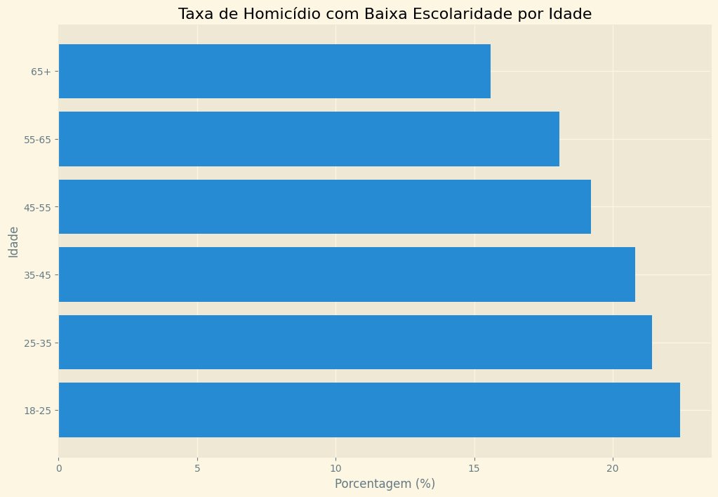

## Análise segmentada por idade

Em média, 19.59% das pessoas de cada faixa etária que morrem tem baixa escolaridade em relação ao total de homicídios.

Conclusivamente, verifica-se que não existem evidências para uma idade que influencia na mortalidade a partir da baixa escolaridade. Nesse caso, a taxa de homicídio por baixa escolaridade por idade se mantém praticamente constante com um desvio-padrão de 0,025 (pouca dispersão) em relação ao total de homicídios.

## Análise segmentada por raça

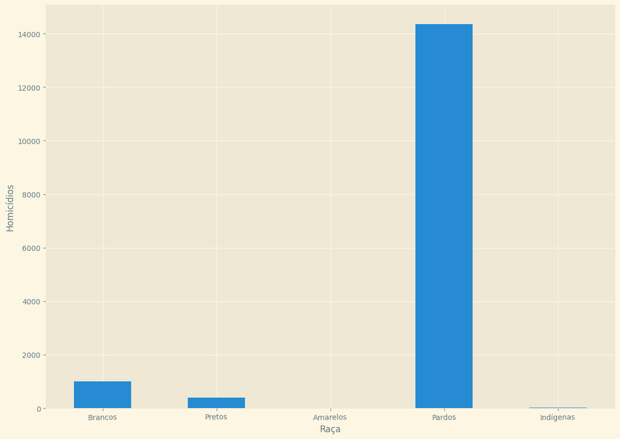

## Análise segmentada por raça

|  | Taxa |
| --- | --- |
| Pardas | 89,47% |
| Brancas | 6,82% |
| Pretas | 3,56% |

Nesse caso é observado uma predominância da raça parda em relação à taxa de homicídio por pessoa com baixa escolaridade.

## Análise segmentada por sexo

|  | Taxa |
| --- | --- |
| Masculino | 93,06% |
| Feminino | 6,94% |

Em relação ao sexo, verifica-se uma predominância maior em relação ao sexo masculino no que se refere à taxa de homicídio por baixa escolaridade.

## Análise segmentada por ocupação

Principais ocupações das vítimas com baixa escolaridade, de acordo com a Classificação Brasileira de Ocupações.

|  | Ocupação |
| --- | --- |
| 1º | Trabalhador terciário ou autônomo |
| 2º | Trabalhador rural |
| 3º | Servente de Obras |
| 4º | Caseiro |
| 5º | Pedreiro |

## Análise segmentada por ocupação

Percebeu-se que, quem tem baixa escolaridade, normalmente trabalha no rural ou é autônomo. Além disso, observou-se que as pessoas com baixa escolaridade têm menos oportunidades de carreira.

Juntando as 5 ocupações, elas representam cerca de 59,32% dos homicídios por baixa escolaridade na Paraíba.

## Análise do perfil mais comum

- Do total das vítimas, 21,20% dessas possuiam apenas o Ensino Fundamental 1.
- Das quais 34,69% possuiam entre 25 e 35 anos de idade.
- 90,24% dessas vítimas eram pardas.
- 94,12% eram homens.
- 11,39% se enquadra no código 622020 da Classificação Brasileira de Ocupações, trabalhador volante da agricultura.

## Análise do perfil mais comum

|  | Perfil |
| --- | --- |
| Educação | Fundamental I |
| Idade | Entre 25 a 35 anos |
| Raça/Cor | Pardos |
| Sexo | Homens |
| Ocupação | Trabalhadores rurais |

## Análise do perfil mais comum

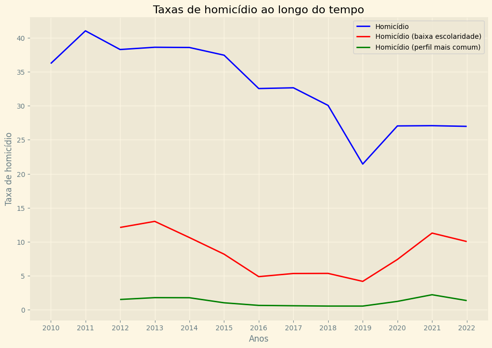

## Análise do perfil mais comum

Analisando o período de 2016-2019, verificou-se que a taxa de homicídio total teve uma queda, enquanto que as taxas de homicídio (baixa escolaridade) e homicídio (perfil mais comum) se mantiveram praticamente constantes.

## Análise do perfil mais comum

Verificou-se isso através do desvio-padrão, onde nesse período selecionado de 2016 a 2019, a taxa total teve um desvio-padrão de 5,399, enquanto que a de baixa escolaridade teve um desvio-padrão de 0,552 e a do perfil mais comum teve 0,048.

## Análise do perfil mais comum

$$\frac{5,399 (\text{desvio-padrão total})}{0,048 (\text{desvio-padrão perfil})}=112,5$$

Dado isso, observa-se uma diferença de aproximadamente 112,5 vezes na dispersão dos dados nesse período. Isso mostra que, mesmo variando bastante a taxa de homicídio ao longo dos anos, o perfil mais comum permaneceu com uma taxa de homicídio praticamente constante.

# Conclusão

Dentre esses fatores, a idade predominante em relação a taxa de homicídio por baixa escolaridade é de 18-35 anos, que corresponde a aproximadamente 67,96% dos casos.

A raça com maior número de casos é a raça parda, com aproximadamente 90% em relação ao total de homicídios com baixa escolaridade.

# Conclusão

O sexo mais evidente é o masculino, com 93,06% dos casos totais com baixa escolaridade.

As principais ocupações são a de trabalhador terciário/autônomo e a de trabalhador rural, representando 37,52% dos casos com baixa escolaridade. Juntando as 5 ocupações mais frequentes, elas representam cerca de 59,32% dos homicídios por baixa escolaridade na Paraíba.

# Conclusão

Dessa maneira, é preenchida a lacuna dos estudos que abordam a taxa de homicídio na Paraíba e sua relação com a baixa escolaridade, assim como os fatores que evidenciam influências nessa taxa.

## Limitações

Ao realizar a análise primária dos dados de homicídios, percebeu-se que 74,72% dos dados de escolaridade ou estavam faltando ou foram ignorados. Isso implicou em uma análise com um volume menor de dados, o que tornou o processo de análise mais restrito.

## Limitações

Percebeu-se que não foram catalogados dados dos anos de 2010 a 2011 para pessoas com baixa escolaridade (que tem até o fundamental II) no SIM.

## Limitações

Houve uma pequena diferença entre os dados disponíveis para o público através do IPEA e os dados coletados para análise através do SIM e do IBGE, pois não conseguiu-se o acesso dos dados restantes de homicídios na Paraíba pela Secretaria Estadual de Segurança Pública e Defesa Social devido a inacessibilidade dos dados.

## Sugestões

Sugerimos através desse estudo, em prol da facilitação da obtenção de dados para estudos posteriores, a junção dos dados do SIM com os dados de mortalidade da Secretaria Estadual de Segurança Pública e Defesa Social.

## Sugestões

Com esses achados, cabe ao governo do estado da Paraíba tomar decisões estratégicas a fim de aprimorar as políticas públicas que tratam do o acesso à educação no estado para toda a população, almejando em uma possível redução da taxa de homicídio geral na Paraíba.

## Sugestões

**Programas de Educação Integral**:

Implementação de escolas de tempo integral, em comunidades de baixa renda, oferecendo atividades extracurriculares como esportes, artes e cursos profissionalizantes.

Objetivo: Manter os jovens em atividades educativas durante o dia inteiro, diminuindo o tempo ocioso que pode levar à exposição à criminalidade.

## Sugestões

**Programas de Educação de Jovens e Adultos (EJA)**:

Ampliação e fortalecimento dos programas de Educação de Jovens e Adultos (EJA), oferecendo cursos supletivos presenciais e à distância para adultos que não concluíram o ensino fundamental ou médio.

Objetivo: Proporcionar a esses adultos a oportunidade de completar a escolaridade básica, aumentando suas chances de ingresso no mercado de trabalho formal e reduzindo sua vulnerabilidade social.

## Sugestões

**Cursos Profissionalizantes Gratuitos**:

Criação de programas de capacitação técnica e profissional voltados para adultos de baixa escolaridade, com cursos em áreas com alta demanda de emprego, como construção civil, eletricidade, culinária, serviços gerais e tecnologia.

Objetivo: Oferecer qualificação para que adultos com baixa escolaridade possam se inserir no mercado de trabalho ou se tornar empreendedores, diminuindo a dependência de atividades ilegais.

## Sugestões

**Apoio Psicossocial e Familiar**:

Criação programas de apoio psicossocial e familiar para pessoas em situação de vulnerabilidade, integrados às iniciativas de educação e capacitação. Psicólogos, assistentes sociais e profissionais de saúde podem auxiliar nesse processo.

Objetivo: Tratar fatores que possam levar à violência e à criminalidade, como traumas, abuso de substâncias e problemas familiares, criando um ambiente mais favorável à educação e ao trabalho.

# Referências

Gleditsch, Kristian Skrede, Mauricio Rivera, and Bárbara A. Zárate‐Tenorio. 2021. “Can Education Reduce Violent Crime? Evidence from Mexico Before and After the Drug War OnsetCan Education Reduce Violent Crime? Evidence from Mexico Before and After the Drug War Onset.” *Taylor & Francis* 58. https://doi-org.ez15.periodicos.capes.gov.br/10.1080/00220388.2021.1971649.

Peres, Maria Fernanda Tourinho, Diego Vicentin, Marcelo Batista Nery, Renato Sérgio de Lima, Edinilsa Ramos de Souza, Magdalena Cerda, Nancy Cardia, and Sérgio Adorno. 2011. “Queda Dos Homicídios Em São Paulo, Brasil: Uma Análise Descritiva.” *Rev Panam Salud Publica* 29: 17–26.

Segurança Pública, Fórum Brasileiro de. 2023. “17º Anuário Brasileiro de Segurança Pública.” *Fórum Brasileiro de Segurança Pública*. https://forumseguranca.org.br/wp-content/uploads/2023/07/anuario-2023.pdf.

Wanzinack, Clóvis, Marcos Cláudio Signorelli, and Clóvis Reis. 2018. “Homicides and Socio-Environmental Determinants of Health in Brazil: A Systematic Literature Review.” *Escola Nacional de Saúde Pública, Fundação Oswaldo Cruz* 34. https://doi.org/10.1590/0102-311X00012818.